# International Trade Network Analysis (2012 - 2021)

Network Analysis of 10 years Trade Data for top producers of Copper, Lithium, and Graphite

Abhinav Kumar (University of Massachusetts, Amherst)  
2022-05-27

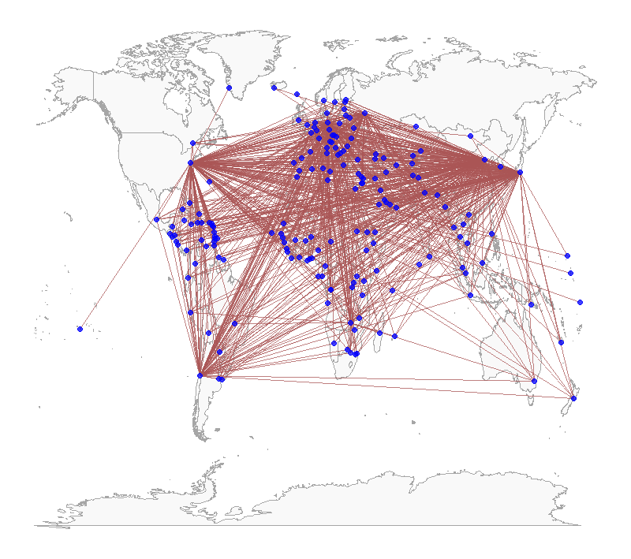

```r
knitr::include_graphics('./Copper Trade Network (2012 - 2021).png')
```

## Introduction

This study has been designed to explore the trade relations that have developed over 10 years from 2012 to 2021 for top producers of Copper, Lithium, and Graphite. These commodities have been selected to study how has the battery and electric international trade economy evolved. The data has been extracted using UN Comtrade API. The data extraction code will be attached separately. There are many restrictions while extracting data from UN Comtrade website. In a day only 50000 hits are allowed. The export or import data can be extracted for one country at a time. We cannot extracted trade data for multiple countries at one time. This is a restriction imposed by the API. In case more than 50000 hits are required per day, then license needs to be procured from UN Comtrade. As the data is required only for academic study purposes, the extraction has been limited to 50000 only. However, in order to extract the data, multiple runs and iterations had to be made over a period of four days.

The commodities for the study have been selected using international Harmonized System (HS) codes for trade. The commodities selected are in the input form rather than value added finished products form to understand the production pattern of producers and consumption pattern of importers. The HS codes selected are as below:

1. Copper - “2603”, “7406”, “7404”
2. Lithium - “283691”, “282520”
3. Graphite - “3801”, “2504”

In the data set we have the details of exports and imports trade values in USD for the three commodities. For the sake of this initial study, we will only look at one commodity to to develop an understanding. In future, all the commodities will be used to understand the overall trade scenario. Although, we have extracted at least two HS codes across the three commodities, for the purpose of the study, various classes/type of the same commodity will be treated as one. Like copper has three HS codes and for purpose of this study all the three HS codes will be treated as copper.

```r
library(readr)
library(tidyverse)
library(igraph)
library(statnet)
library(ITNr)
library(concordance)
library(corrr)
trade <- read_csv(file.choose())

trade_copper <- trade %>% filter(commodity_code == "2603" | commodity_code == "7406" | commodity_code == "7404")
```

```r
# Converting all Imports to Exports by interchanging the reporter and partner

trade_copper %>%
  filter(trade_flow == "Import") %>%
  mutate(aux = reporter, reporter = partner, partner = aux,
         trade_flow = "Export") %>%
  select(-aux) -> tmp
rbind(trade_copper, tmp) %>%
  filter(trade_flow == "Export") -> total_trade_clean

total_trade_clean <- total_trade_clean[, -c(3,5)] #removing reporter_iso and partner_iso columns

head(total_trade_clean)
```

```
# A tibble: 6 x 7
   year trade_flow reporter partner  commodity_code commodity
  <dbl> <chr>      <chr>    <chr>             <dbl> <chr>
1  2012 Export     Chile    Brazil             2603 Copper ores and c~
2  2012 Export     Chile    Bulgaria           2603 Copper ores and c~
3  2012 Export     Chile    Canada             2603 Copper ores and c~
4  2012 Export     Chile    China              2603 Copper ores and c~
5  2012 Export     Chile    Finland            2603 Copper ores and c~
6  2012 Export     Chile    Germany            2603 Copper ores and c~
# ... with 1 more variable: trade_value_usd <dbl>
```

```r
# creating igraph network

X <- data.frame("From" = total_trade_clean$reporter,
                "To" = total_trade_clean$partner,
                "weight" = total_trade_clean$trade_value_usd)

net.ig <- graph.data.frame(X, directed = TRUE)
E(net.ig)$weight <- total_trade_clean$trade_value_usd

adj <- get.adjacency(net.ig, sparse = FALSE)

summary(net.ig)
```

```
IGRAPH 27a8c3d DNW- 205 10244 --
+ attr: name (v/c), weight (e/n)
```

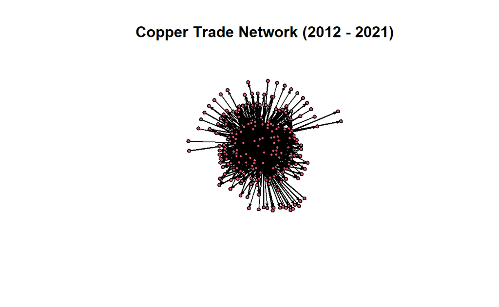

```r
# Coercing igraph object to statnet object

network <- intergraph::asNetwork(net.ig)

# plotting the copper export network
set.seed(007)
plot(network,  main = "Copper Trade Network (2012 - 2021)")
```

## Network Structure

**The edgelist consists of 205 nodes and 10244 ties. The weight of the edges is the value of trade in USD that is being generated due to exports of copper from one nation to other. The edgelist is directed one as exports is unidirectional from one nation to the other.**

```r
print(paste0("The number of vertices in the network is:",vcount(net.ig)))
```

```
[1] "The number of vertices in the network is:205"
```

```r
print(paste0("The number of edges in the network is:",ecount(net.ig)))
```

```
[1] "The number of edges in the network is:10244"
```

## Network Exploration basis time interval (years)

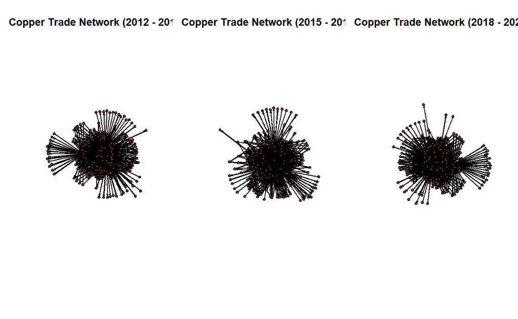

```r
## network data for 2012, 2013, 2014
cop121314 <- total_trade_clean %>% filter(year == "2012" | year == "2013" | year == "2014")

X121314 <- data.frame("From" = cop121314$reporter,
                "To" = cop121314$partner,
                "weight" = cop121314$trade_value_usd)

net121314.ig <- graph.data.frame(X121314, directed = TRUE)
E(net121314.ig)$weight <- cop121314$trade_value_usd

adj121314 <- get.adjacency(net121314.ig, sparse = FALSE)


## network data for 2015, 2016, 2017
cop151617 <- total_trade_clean %>% filter(year == "2015" | year == "2016" | year == "2017")

X151617 <- data.frame("From" = cop151617$reporter,
                "To" = cop151617$partner,
                "weight" = cop151617$trade_value_usd)

net151617.ig <- graph.data.frame(X151617, directed = TRUE)
E(net151617.ig)$weight <- cop151617$trade_value_usd

adj151617 <- get.adjacency(net151617.ig, sparse = FALSE)


## network data for years 2018, 2019, 2020, 2021
cop18192021 <- total_trade_clean %>% filter(year == "2018" | year == "2019" | year == "2020" | year == "2021")

X18192021 <- data.frame("From" = cop18192021$reporter,
                "To" = cop18192021$partner,
                "weight" = cop18192021$trade_value_usd)

net18192021.ig <- graph.data.frame(X18192021, directed = TRUE)
E(net18192021.ig)$weight <- cop18192021$trade_value_usd

adj18192021 <- get.adjacency(net18192021.ig, sparse = FALSE)

## getting statnet network objects to plot for the 3 time intervals

network121314 <- intergraph::asNetwork(net121314.ig)
network151617 <- intergraph::asNetwork(net151617.ig)
network18192021 <- intergraph::asNetwork(net18192021.ig)

set.seed(008)

par(mfrow = c(1,3))
plot(network121314,  main = "Copper Trade Network (2012 - 2014)")
plot(network151617,  main = "Copper Trade Network (2015 - 2017)")
plot(network18192021,  main = "Copper Trade Network (2018 - 2021)")
```

```r
network121314
```

```
 Network attributes:
  vertices = 191
  directed = TRUE
  hyper = FALSE
  loops = TRUE
  multiple = TRUE
  bipartite = FALSE
  total edges= 3217
    missing edges= 0
    non-missing edges= 3217

 Vertex attribute names:
    vertex.names

 Edge attribute names not shown
```

```r
network151617
```

```
 Network attributes:
  vertices = 175
  directed = TRUE
  hyper = FALSE
  loops = TRUE
  multiple = TRUE
  bipartite = FALSE
  total edges= 3074
    missing edges= 0
    non-missing edges= 3074

 Vertex attribute names:
    vertex.names

 Edge attribute names not shown
```

```r
network18192021
```

```
 Network attributes:
  vertices = 182
  directed = TRUE
  hyper = FALSE
  loops = TRUE
  multiple = TRUE
  bipartite = FALSE
  total edges= 3953
    missing edges= 0
    non-missing edges= 3953

 Vertex attribute names:
    vertex.names

 Edge attribute names not shown
```

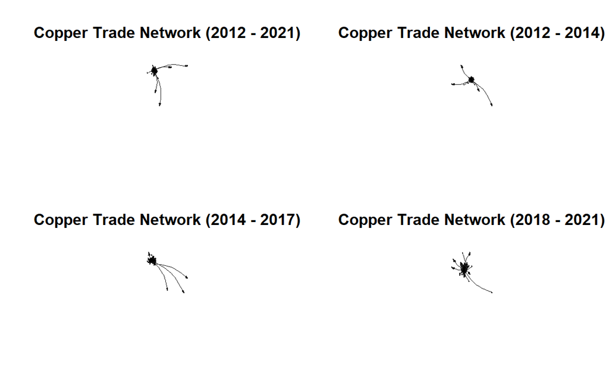

```r
# plotting the igraph object

set.seed(191014)
par(mfrow = c(2,2))

netigs <- simplify(net.ig, remove.loops = T)

plot(netigs, vertex.size = 5, vertex.label = NA, edge.curved = .3, vertex.color = "blue", edge.arrow.size = .1, edge.width = .5, edge.color = "grey10", main = "Copper Trade Network (2012 - 2021)")

net121314igs <- simplify(net121314.ig, remove.loops = T)

plot(net121314igs, vertex.size = 5, vertex.label = NA, edge.curved = .3, vertex.color = "green", edge.arrow.size = .1, edge.width = .5, edge.color = "grey10", main = "Copper Trade Network (2012 - 2014)")

net151617igs <- simplify(net151617.ig, remove.loops = T)

plot(net151617igs, vertex.size = 5, vertex.label = NA, edge.curved = .3, vertex.color = "red", edge.arrow.size = .1, edge.width = .5, edge.color = "grey10", main = "Copper Trade Network (2014 - 2017)")

net18192021igs <- simplify(net18192021.ig, remove.loops = T)

plot(net18192021igs, vertex.size = 5, vertex.label = NA, edge.curved = .3, vertex.color = "orange", edge.arrow.size = .1, edge.width = .5, edge.color = "grey10", main = "Copper Trade Network (2018 - 2021)")
```

```r
#exploring the dyad census
dyad_census(net.ig)
```

```
$mut
[1] 413

$asym
[1] 366

$null
[1] 20131
```

```r
#calculating reciprocity
reciprocity(net.ig)
```

```
[1] 0.6163485
```

**The minimal structural element in a social network is a dyad. The complete trade network can be broken down into constitutent parts. These parts are called motifs. A motif has two nodes that is called a dyad. In a dyad, both the members have good bargaining power. There are “413” mutually directed relationships among pair of countries trading copper over 10 years time frame.**

**The reciprocity is about 62%, which shows the chance with which the nations are trading. This confirms that these pair of countries are exporting and importing copper. So the producer nations (ego) efforts are reciprocated by the importer nations (alters). There are 366 countries that have just exported copper without any imports from the countries in the given sample. There are 20131 pair of countries with no trade relationships. These asymmetric dyads reflect a hierarchy in terms of exporting countries.**

```r
# exploring triad census
triad.census(network)
```

```
         003   012   102 021D 021U 021C  111D 111U 030T 030C   201
[1,] 1308003 29844 27302 1343 6604 2376 15886 6675    9    5 15408
     120D 120U 120C 210 300
[1,]  160   24  125 587 559
```

**Triads consist of three nodes and are more complex than dyads. Here we can observe 16 isomorphic classes of triads. As per triad census, there are 1308003 empty triads. These nations a part of null triad are not having any trade relations. 1343 triads and 6604 triads are vacuously transitive. There is a chance that the trading nations in these triads might make it a complete triplet by trading between the two nations that are not trading as of now. Total of 9 perfectly transitive triads exist in the network that are trading copper among themselves. A total of 743 closed transitive tralds exists in the network among trading nations.**

```r
is_directed(net.ig)
```

```
[1] TRUE
```

```r
is_weighted(net.ig)
```

```
[1] TRUE
```

```r
is_bipartite(net.ig)
```

```
[1] FALSE
```

**The network developed is directed due the nature of trade i.e. export and the network is weighted with with the export trade value in USD.**

```r
#get global clustering cofficient: igraph
transitivity(net.ig, type="global")
```

```
[1] 0.08362588
```

```r
#get average local clustering coefficient: igraph
transitivity(net.ig, type="average")
```

```
[1] 0.9476711
```

## Path Lengths

**The average path length in the weighted trade network is 171196.8. Here, we can explore the distance travelled between two trading nations. For this study purpose we have taken India and China as the trading nations. Using distances function we calculate the geodesic distance (the shortest path distance between India and china). The distance between India and China is 11. Te shortest path between the two nations involves 4 nodes.**

```r
average.path.length(net.ig)
```

```
[1] 171196.8
```

```r
distances(net.ig,"China", "India")
```

```
      India
China    11
```

```r
shortest_paths(net.ig,"China", "India")$vpath[[1]]
```

```
+ 4/205 vertices, named, from 27a8c3d:
[1] China              France             Russian Federation
[4] India
```

```r
gd<- all_shortest_paths(net.ig,"China", "India", weights = NA)
gd$nrgeo# geodesic distance.
```

```
  [1] 26 47 39  0 41  1  9 18 14  1  3  9 22 18  7 11  8  0  6  7 14
 [22] 10  0  9 11  9  8  4 11  0  4  0 19 10  9  1 12  2  2  8 10  0
 [43]  1  9 12 12  9  1  2  0  0  0  0  0  5  0  0  9  0  0  3  0  0
 [64]  3  0  7  0  0  0  0  0  0  0  0  0 23  0  0  1  8  1  7  1  1
 [85]  0  9  1  4  6  0  0  0  0  0  4  0  4  0  9  0  1  2  0  0  1
[106]  2  0  2  2  0  0  0  0  9  2  3  0  9  9  0  0  0  1  1  0  3
[127]  3  0  0  0  0  0  0  9  2  2  0  0  1  0 15  9  1  4  0  1  0
[148]  0  0  2  1  0  0  0  0  0  0  0  0  1  0  0  0  0  0  0  0  0
[169]  0  2  6  0  0  3  4  0  0  0  0  0  0  0  0  4  0  0  0  0  0
[190]  0  0  4  0  0  1  0  1  0  0  0  0  0  0  0  0
```

```r
gd<- all_shortest_paths(net.ig,"China", "India")
gd$nrgeo
```

```
  [1] 1 1 1 0 0 1 1 1 1 1 1 1 1 0 0 1 0 1 0 0 1 1 0 0 1 0 0 0 1 1 0 0
 [33] 0 0 1 0 0 0 0 1 0 0 0 0 1 0 0 0 0 0 1 0 0 0 0 0 0 0 0 0 0 0 0 0
 [65] 0 1 0 0 0 0 0 0 0 0 0 1 1 0 0 0 0 0 0 0 0 0 0 0 0 0 1 0 1 0 1 0
 [97] 1 0 0 0 0 0 0 0 1 0 0 1 1 0 0 0 0 0 1 1 0 0 0 0 0 0 0 1 0 0 0 0
[129] 0 0 0 0 0 0 0 0 0 0 0 0 1 0 1 1 0 0 0 0 0 1 0 0 0 0 0 0 0 0 0 1
[161] 0 0 0 0 0 0 0 0 0 0 1 0 0 1 0 0 0 0 0 0 0 0 0 0 0 0 0 0 0 0 0 1
[193] 0 0 0 0 1 1 0 0 0 0 0 0 0
```

## Density

**Density of a network is the ratio of the number of edges and the number of possible edges. Here we can observe that the trade network density with and without the loop is almost same resulting to 0.24. Now as this network has multiple edges, the trade network density cannot be interpreted clearly as density is ill-defined.**

```r
graph.density(net.ig)
```

```
[1] 0.2449546
```

```r
graph.density(net.ig, loops=TRUE)
```

```
[1] 0.2437597
```

## Degree

**Degree of a node is equal to the number of incoming and outgoing links it has. The degree measures the node centrality or a popularity of a node. In this case degree represents the number of trade linkages a country has. In the trade network Germany has the highest number of overall trade (exports and imports) links followed by China and USA. In order to further understand the degree attribute at country level, a new data frame “trade.nodes” is being prepared to explore and analyze. In the rest of the section of this study we will analyze various network parameters. In order to do so, all the parameters will be stored in a data frame “trade.nodes”. From trade.nodes, we can observe that “Germany”, and “USA” have high number of exports linkage given the out degree parameter is very high among all nations.**

```r
sort(igraph::degree(net.ig)[1:10], decreasing = T)
```

```
                         Germany                            China
                            3110                             2515
                             USA                            Japan
                            2368                             1469
                           Chile               Russian Federation
                             956                              686
                          Zambia                        Australia
                             202                              158
                           Congo Bolivia (Plurinational State of)
                              63                               59
```

```r
##creating a dataframe

trade.nodes<-data.frame(name=V(net.ig)$name, degree=igraph::degree(net.ig))
```

## In Degree and Out Degree

```r
trade.nodes<-trade.nodes %>%
    mutate(indegree=igraph::degree(net.ig, mode="in", loops=FALSE),
           outdegree=igraph::degree(net.ig, mode="out", loops=FALSE)) %>%
  arrange(desc(degree))

knitr::kable(head(trade.nodes))
```

|  | name | degree | indegree | outdegree |
| --- | --- | --- | --- | --- |
| Germany | Germany | 3110 | 1614 | 1496 |
| China | China | 2515 | 1763 | 714 |
| USA | USA | 2368 | 944 | 1424 |
| Japan | Japan | 1469 | 996 | 473 |
| Chile | Chile | 956 | 378 | 558 |
| Russian Federation | Russian Federation | 686 | 343 | 343 |

```r
# Summarize by Group
trade.nodes%>%
  group_by(name)%>%
  summarise_all(funs(mean, n())) %>%
  arrange(desc(degree_mean))
```

```
# A tibble: 205 x 7
   name   degree_mean indegree_mean outdegree_mean degree_n indegree_n
   <chr>        <dbl>         <dbl>          <dbl>    <int>      <int>
 1 Germa~        3110          1614           1496        1          1
 2 China         2515          1763            714        1          1
 3 USA           2368           944           1424        1          1
 4 Japan         1469           996            473        1          1
 5 Chile          956           378            558        1          1
 6 Russi~         686           343            343        1          1
 7 India          228           117            111        1          1
 8 Rep. ~         221           125             96        1          1
 9 Canada         216            92            124        1          1
10 Unite~         212            97            115        1          1
# ... with 195 more rows, and 1 more variable: outdegree_n <int>
```

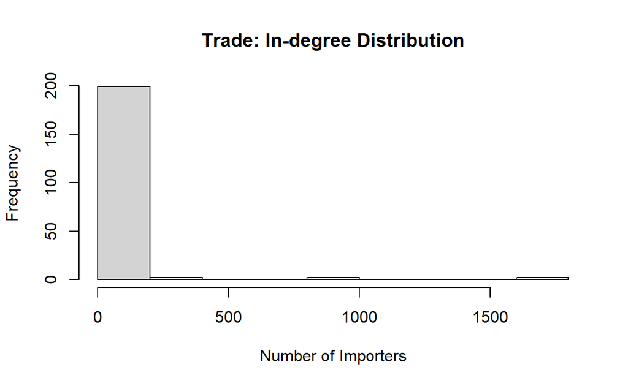

```r
#create a histogram of trade Indegree
hist(trade.nodes$indegree, main="Trade: In-degree Distribution", xlab = "Number of Importers")
```

**The in-degree distribution of the overall trade network is positively skewed. Similarly the out-degree distribution of the exporting nations is also positively skewed. Now this degree distribution will be used to analyze social status or centrality in the trade network.**

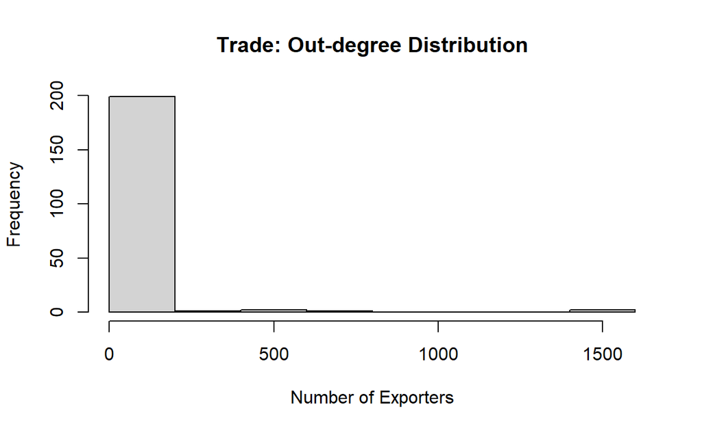

```r
#create a histogram of trade Out degree

hist(trade.nodes$outdegree, main="Trade: Out-degree Distribution", xlab="Number of Exporters")
```

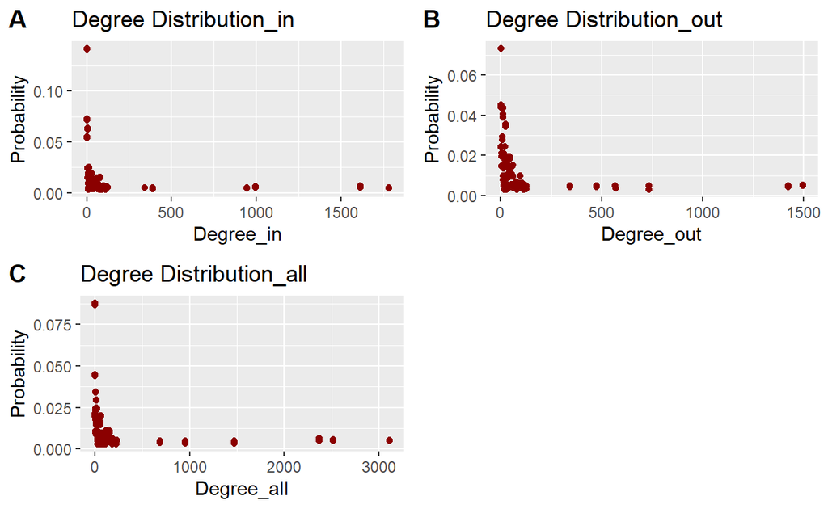

```r
#  probability plot of degree scores over the whole network using ITNr package

ITNdegdist(net.ig)
```

## Centrality and Centralization

**The centrality of a node is a measure of prominence of the node relative to other nodes in the network. In the trade network we will analyze various types of centrality measures for the exporting nations and analyze the most central nation in the overall network. Centralization is a property of overall graph. It compares the most central node to the other nodes in the network. The inward centralization score for the trade network in this case for the given sample is “8.44” which is more than the export centralization score which is “7.12”. This is in sync with our analysis as we have take export data of top copper producing nations and the trade network is expected to have more inward transactions as the handful of nations are exporting to the world. However, interestingly these handful nations are also importing copper from much smaller producers such as “Eritrea”, “Rawanda”, “Sudan”, etc. in very small loads. While “Germany” has the highest degree linkage in the overall trade network, its imports are more than the exports. However, these are just the links and not the amount of trade information. Basis the eigenvalue centrality measure, that determines how important the neighborhood of the nodes is in the network are and higher the eigenvalue centrality, the more important the neighbors of that node are with respect to other nodes in the network. We can infer from the centrality dataframe below that “Russian Federation” has the highest eigenvalue centrality. Hence, “Russian Federation” could be the most influential trading nation in the network. Then, derived and reflected Eigenvector centrality has been computed to better understand whether the influence is more observed in the neighborhood of the nodes or is it more observed on the strength of the node itself**

```r
#get network centralization score: igraph

centr_degree(net.ig, loops = FALSE, mode="in")$centralization
```

```
[1] 8.439062
```

```r
centr_degree(net.ig, loops = FALSE, mode="out")$centralization
```

```
[1] 7.123823
```

##Highest and Lowest In and Out degrees

```r
trade.nodes%>%
  arrange(desc(indegree))%>%
  slice(1:10)
```

```
                                 name degree indegree outdegree
China                           China   2515     1763       714
Germany                       Germany   3110     1614      1496
Japan                           Japan   1469      996       473
USA                               USA   2368      944      1424
Chile                           Chile    956      378       558
Russian Federation Russian Federation    686      343       343
Rep. of Korea           Rep. of Korea    221      125        96
India                           India    228      117       111
Belgium                       Belgium    193      113        80
Other Asia, nes       Other Asia, nes    186      107        79
```

```r
trade.nodes%>%
  arrange(indegree, decreasing = T)%>%
  slice(1:10)
```

```
                               name degree indegree outdegree
Sudan                         Sudan     21        0        21
Togo                           Togo     21        0        21
Saint Maarten         Saint Maarten     10        0        10
Eritrea                     Eritrea      9        0         9
Rwanda                       Rwanda      9        0         9
Seychelles               Seychelles      7        0         7
Montserrat               Montserrat      3        0         3
Anguilla                   Anguilla      3        0         3
Oceania, nes           Oceania, nes      3        0         3
Other Europe, nes Other Europe, nes      3        0         3
```

```r
trade.nodes%>%
  arrange(desc(outdegree))%>%
  slice(1:10)
```

```
                                 name degree indegree outdegree
Germany                       Germany   3110     1614      1496
USA                               USA   2368      944      1424
China                           China   2515     1763       714
Chile                           Chile    956      378       558
Japan                           Japan   1469      996       473
Russian Federation Russian Federation    686      343       343
Zambia                         Zambia    202       75       127
Canada                         Canada    216       92       124
United Kingdom         United Kingdom    212       97       115
Mexico                         Mexico    189       76       113
```

```r
trade.nodes%>%
  arrange(outdegree)%>%
  slice(1:10)
```

```
                                         name degree indegree
State of Palestine         State of Palestine      7        7
Andorra                               Andorra      2        2
Chad                                     Chad      2        2
Br. Indian Ocean Terr. Br. Indian Ocean Terr.      2        2
Cocos Isds                         Cocos Isds      1        1
South Sudan                       South Sudan      1        1
Maldives                             Maldives      1        1
Greenland                           Greenland      1        1
Christmas Isds                 Christmas Isds      1        1
French Polynesia             French Polynesia      1        1
                       outdegree
State of Palestine             0
Andorra                        0
Chad                           0
Br. Indian Ocean Terr.         0
Cocos Isds                     0
South Sudan                    0
Maldives                       0
Greenland                      0
Christmas Isds                 0
French Polynesia               0
```

## Network Status

```r
#add eigenvector centrality to node measures
temp <- centr_eigen(net.ig,directed=T)
trade.nodes$eigen<-temp$vector

#arrange descending and return top 5 nodes
arrange(trade.nodes, desc(eigen)) %>%
  slice(1:5)
```

```
                                 name degree indegree outdegree
Russian Federation Russian Federation    686      343       343
China                           China   2515     1763       714
USA                               USA   2368      944      1424
Chile                           Chile    956      378       558
Germany                       Germany   3110     1614      1496
                       eigen
Russian Federation 1.0000000
China              0.9259295
USA                0.7377752
Chile              0.6849924
Germany            0.4417632
```

## Derived and Reflected Centrality

**In order to claculate the centralities, we are creating here adjacency matrix to do rest of the analysis.**

```r
matrix <- as.matrix(as_adjacency_matrix(net.ig, attr = "weight"))

#square the adjacency matrix
matsq<-t(matrix) %*% matrix

#Calculate the proportion of reflected centrality.
trade.nodes$rc<-diag(matsq)/rowSums(matsq)

#replace missing values with 0
trade.nodes$rc<-ifelse(is.nan(trade.nodes$rc),0,trade.nodes$rc)

#Calculate received eigenvalue centrality
trade.nodes$eigen.rc<-trade.nodes$eigen*trade.nodes$rc

#Calculate the proportion of derived centrality.
trade.nodes$dc<-1-diag(matsq)/rowSums(matsq)

#replace missing values with 0
trade.nodes$dc<-ifelse(is.nan(trade.nodes$dc),1,trade.nodes$dc)

#Calculate received eigenvalue centrality
trade.nodes$eigen.dc<-trade.nodes$eigen*trade.nodes$dc
```

```r
filter(trade.nodes,name%in%c("China","India", "Germany", "USA","Zambia", "Chile", "Japan"))
```

```
           name degree indegree outdegree       eigen           rc
Germany Germany   3110     1614      1496 0.441763202 2.039639e-02
China     China   2515     1763       714 0.925929524 6.228063e-02
USA         USA   2368      944      1424 0.737775185 2.626484e-01
Japan     Japan   1469      996       473 0.005936172 1.399798e-06
Chile     Chile    956      378       558 0.684992375 1.183059e-01
India     India    228      117       111 0.062075183 7.805447e-01
Zambia   Zambia    202       75       127 0.119926179 1.098478e-02
            eigen.rc        dc    eigen.dc
Germany 9.010373e-03 0.9796036 0.432752829
China   5.766748e-02 0.9377194 0.868262046
USA     1.937755e-01 0.7373516 0.543999727
Japan   8.309441e-09 0.9999986 0.005936164
Chile   8.103867e-02 0.8816941 0.603953707
India   4.845246e-02 0.2194553 0.013622727
Zambia  1.317363e-03 0.9890152 0.118608816
```

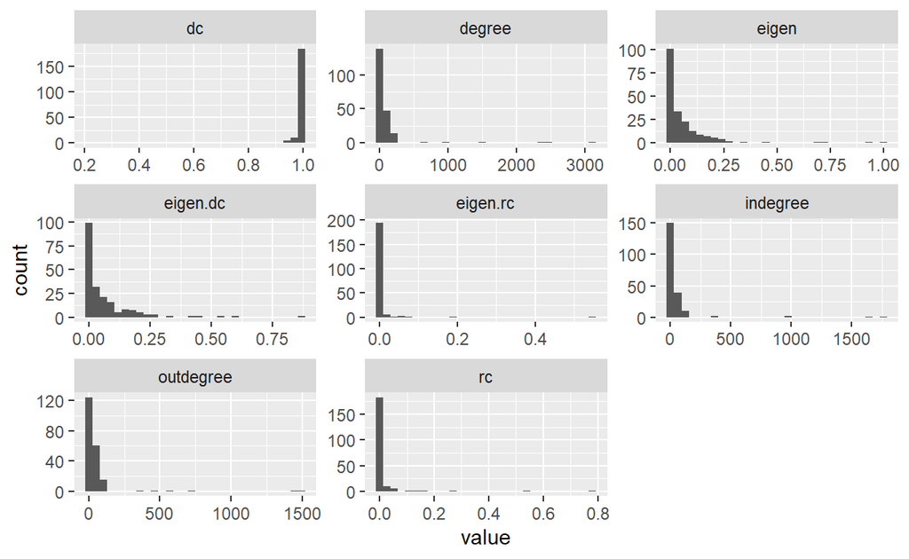

```r
trade.nodes%>%
  select(-name) %>%
  gather() %>%
  ggplot(aes(value)) +
    geom_histogram() +
    facet_wrap(~key, scales = "free")
```

```r
temp<-trade.nodes %>%
  select(degree,indegree,outdegree,eigen,eigen.rc,eigen.dc)%>%
  correlate() %>%
  rearrange()

temp
```

```
# A tibble: 6 x 7
  term      degree indegree outdegree eigen.dc  eigen eigen.rc
  <chr>      <dbl>    <dbl>     <dbl>    <dbl>  <dbl>    <dbl>
1 degree    NA        0.977     0.963    0.707  0.688    0.349
2 indegree   0.977   NA         0.883    0.692  0.658    0.296
3 outdegree  0.963    0.883    NA        0.675  0.674    0.392
4 eigen.dc   0.707    0.692     0.675   NA      0.961    0.458
5 eigen      0.688    0.658     0.674    0.961 NA        0.686
6 eigen.rc   0.349    0.296     0.392    0.458  0.686   NA
```

```r
# fashion helps in printing a clean correlation marix.
fashion(temp)
```

```
       term degree indegree outdegree eigen.dc eigen eigen.rc
1    degree             .98       .96      .71   .69      .35
2  indegree    .98                .88      .69   .66      .30
3 outdegree    .96      .88                .68   .67      .39
4  eigen.dc    .71      .69       .68            .96      .46
5     eigen    .69      .66       .67      .96            .69
6  eigen.rc    .35      .30       .39      .46   .69
```

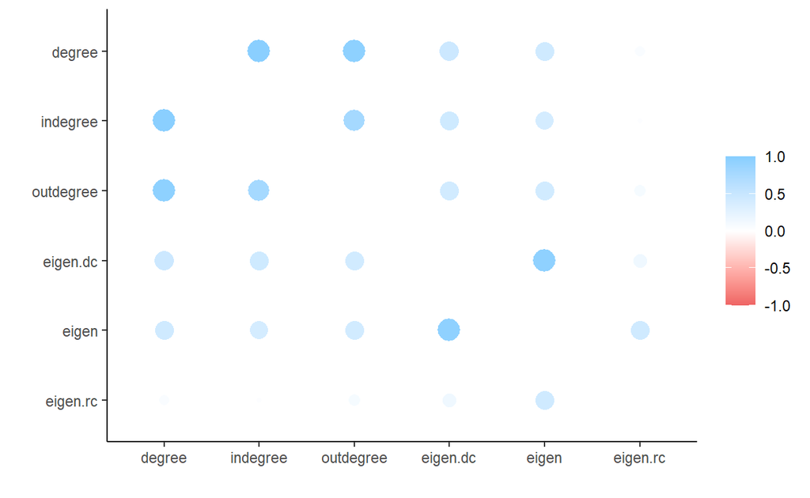

```r
rplot(temp)
```

## Network Brokerage

```r
trade.nodes$close <- sna::closeness(network, gmode="graph", cmode="directed")
trade.nodes%>%
  arrange(desc(close))%>%
  slice(1:10)
```

```
                                 name degree indegree outdegree
China                           China   2515     1763       714
Russian Federation Russian Federation    686      343       343
Chile                           Chile    956      378       558
USA                               USA   2368      944      1424
Rep. of Korea           Rep. of Korea    221      125        96
Germany                       Germany   3110     1614      1496
India                           India    228      117       111
Japan                           Japan   1469      996       473
Mexico                         Mexico    189       76       113
Netherlands               Netherlands    182      100        82
                         eigen           rc     eigen.rc        dc
China              0.925929524 6.228063e-02 5.766748e-02 0.9377194
Russian Federation 1.000000000 5.475166e-01 5.475166e-01 0.4524834
Chile              0.684992375 1.183059e-01 8.103867e-02 0.8816941
USA                0.737775185 2.626484e-01 1.937755e-01 0.7373516
Rep. of Korea      0.331051877 2.100469e-02 6.953644e-03 0.9789953
Germany            0.441763202 2.039639e-02 9.010373e-03 0.9796036
India              0.062075183 7.805447e-01 4.845246e-02 0.2194553
Japan              0.005936172 1.399798e-06 8.309441e-09 0.9999986
Mexico             0.280199019 4.238582e-02 1.187646e-02 0.9576142
Netherlands        0.244951742 4.827443e-02 1.182491e-02 0.9517256
                      eigen.dc     close
China              0.868262046 0.8360656
Russian Federation 0.452483424 0.8259109
Chile              0.603953707 0.7846154
USA                0.543999727 0.7108014
Rep. of Korea      0.324098233 0.6276923
Germany            0.432752829 0.6035503
India              0.013622727 0.5498652
Japan              0.005936164 0.5177665
Mexico             0.268322554 0.5100000
Netherlands        0.233126837 0.5100000
```

## Betweeness centrality

**This centrality measure helps find the node that lies maximum number of times on multiple shortest paths (geodesics) among other nodes. So it tells us which node or nodes in the network are acting as brokers in the network. From the output below we can infer that “Germany”, “USA”, “China”, “Russian Federation”, and “Japan” play the role of a brokers between many trading nations.**

```r
E(net.ig)$weight <- 2**((E(net.ig)$weight - min(E(net.ig)$weight)) / diff(range(E(net.ig)$weight)))
sort((estimate_betweenness(net.ig, cutoff = -1))[1:10], decreasing = T)
```

```
                         Germany                              USA
                       13111.500                        11048.000
                           China               Russian Federation
                        9645.500                         1934.667
                           Japan                           Zambia
                        1765.500                         1055.833
                           Chile                            Congo
                         821.500                           17.000
                       Australia Bolivia (Plurinational State of)
                           0.000                            0.000
```

## Betweeness centralization

```r
centr_betw(net.ig,directed=T)$centralization
```

```
[1] 0.3590233
```

## Network Constraint

```r
trade.nodes$constraint<-constraint(net.ig)
trade.nodes %>%
  arrange(desc(constraint)) %>%
  slice(1:50)
```

```
                                                                         name
Rwanda                                                                 Rwanda
Belize                                                                 Belize
Botswana                                                             Botswana
Afghanistan                                                       Afghanistan
Portugal                                                             Portugal
Jordan                                                                 Jordan
Albania                                                               Albania
Liberia                                                               Liberia
Montenegro                                                         Montenegro
Gabon                                                                   Gabon
Dominica                                                             Dominica
Seychelles                                                         Seychelles
State of Palestine                                         State of Palestine
Malawi                                                                 Malawi
Anguilla                                                             Anguilla
Oceania, nes                                                     Oceania, nes
Other Europe, nes                                           Other Europe, nes
Other Africa, nes                                           Other Africa, nes
Kiribati                                                             Kiribati
Cabo Verde                                                         Cabo Verde
Chad                                                                     Chad
Br. Indian Ocean Terr.                                 Br. Indian Ocean Terr.
Faeroe Isds                                                       Faeroe Isds
North America and Central America, nes North America and Central America, nes
FS Micronesia                                                   FS Micronesia
Burundi                                                               Burundi
Cocos Isds                                                         Cocos Isds
South Sudan                                                       South Sudan
Maldives                                                             Maldives
Greenland                                                           Greenland
Christmas Isds                                                 Christmas Isds
French Polynesia                                             French Polynesia
Tuvalu                                                                 Tuvalu
Guinea-Bissau                                                   Guinea-Bissau
Eswatini                                                             Eswatini
Cameroon                                                             Cameroon
Turkmenistan                                                     Turkmenistan
Mongolia                                                             Mongolia
Grenada                                                               Grenada
```

[output cut: 251 more lines]

```
Cameroon                                1.0000000
Turkmenistan                            1.0000000
Mongolia                                1.0000000
Grenada                                 0.8794093
Somalia                                 0.8608153
United Rep. of Tanzania                 0.8577808
Brunei Darussalam                       0.8497052
Romania                                 0.8168401
Guyana                                  0.8158821
Paraguay                                0.8111296
Nepal                                   0.7920532
New Caledonia                           0.7720527
Hungary                                 0.7661059
Mauritius                               0.7239904
Estonia                                 0.7188106
```

```r
tempo <- as.data.frame(brokerage(network, cl = get.vertex.attribute(network,"reporter"))$raw.nli)
head(tempo)
```

```
            w_I w_O b_IO b_OI b_O       t
Chile    105364   0    0    0   0  105364
Germany 1951399   0    0    0   0 1951399
Japan    287847   0    0    0   0  287847
Congo       162   0    0    0   0     162
USA     1000901   0    0    0   0 1000901
China    913924   0    0    0   0  913924
```

```r
trade.nodes<-trade.nodes %>%
  mutate(broker.tot = tempo$t,
         broker.coord = tempo$w_I,
         broker.itin = tempo$w_O,
         broker.rep = tempo$b_IO,
         broker.gate = tempo$b_OI,
         broker.lia = tempo$b_O)

broker <- trade.nodes %>%
  arrange(desc(broker.tot)) %>%
  slice(1:10)
broker
```

```
                                     name degree indegree outdegree
China                               China   2515     1763       714
Chile                               Chile    956      378       558
Russian Federation     Russian Federation    686      343       343
USA                                   USA   2368      944      1424
Germany                           Germany   3110     1614      1496
Rep. of Korea               Rep. of Korea    221      125        96
India                               India    228      117       111
Singapore                       Singapore    137       86        51
Netherlands                   Netherlands    182      100        82
United Arab Emirates United Arab Emirates    112       61        51
                          eigen          rc    eigen.rc        dc
China                0.92592952 0.062280634 0.057667477 0.9377194
Chile                0.68499237 0.118305942 0.081038668 0.8816941
Russian Federation   1.00000000 0.547516576 0.547516576 0.4524834
USA                  0.73777519 0.262648381 0.193775458 0.7373516
Germany              0.44176320 0.020396387 0.009010373 0.9796036
Rep. of Korea        0.33105188 0.021004695 0.006953644 0.9789953
India                0.06207518 0.780544718 0.048452456 0.2194553
Singapore            0.20667044 0.007531821 0.001556605 0.9924682
Netherlands          0.24495174 0.048274429 0.011824906 0.9517256
United Arab Emirates 0.18541559 0.018571181 0.003443386 0.9814288
                       eigen.dc     close constraint broker.tot
China                0.86826205 0.8360656  0.1203916    1951399
Chile                0.60395371 0.7846154  0.1493694    1000901
Russian Federation   0.45248342 0.8259109  0.1573399     913924
USA                  0.54399973 0.7108014  0.2053428     287847
Germany              0.43275283 0.6035503  0.2201669     105364
Rep. of Korea        0.32409823 0.6276923  0.2246247      67559
India                0.01362273 0.5498652  0.2582780       5173
Singapore            0.20511384 0.5087282  0.2405927        302
Netherlands          0.23312684 0.5100000  0.2429977        269
United Arab Emirates 0.18197221 0.5062035  0.2771472        260
                     broker.coord broker.itin broker.rep broker.gate
China                     1951399           0          0           0
Chile                     1000901           0          0           0
Russian Federation         913924           0          0           0
USA                        287847           0          0           0
Germany                    105364           0          0           0
Rep. of Korea               67559           0          0           0
India                        5173           0          0           0
Singapore                     302           0          0           0
Netherlands                   269           0          0           0
United Arab Emirates          260           0          0           0
                     broker.lia
China                         0
Chile                         0
Russian Federation            0
USA                           0
Germany                       0
Rep. of Korea                 0
India                         0
Singapore                     0
Netherlands                   0
United Arab Emirates          0
```

## Authority

**Authorities are those actors in the network which get many incoming links from hubs, presumably because of their high quality relevant information. In this trade network “Russian Federation” has the highest authority score. This means that it would be closely linked to hubs such as “China”, “USA”, “Chile”, etc.**

```r
trade.nodes$authority <- authority_score(net.ig)$vector

a <- trade.nodes %>%
  arrange(desc(authority))
head(a)
```

```
                                 name degree indegree outdegree
Russian Federation Russian Federation    686      343       343
China                           China   2515     1763       714
USA                               USA   2368      944      1424
Chile                           Chile    956      378       558
Germany                       Germany   3110     1614      1496
Rep. of Korea           Rep. of Korea    221      125        96
                       eigen         rc    eigen.rc        dc
Russian Federation 1.0000000 0.54751658 0.547516576 0.4524834
China              0.9259295 0.06228063 0.057667477 0.9377194
USA                0.7377752 0.26264838 0.193775458 0.7373516
Chile              0.6849924 0.11830594 0.081038668 0.8816941
Germany            0.4417632 0.02039639 0.009010373 0.9796036
Rep. of Korea      0.3310519 0.02100469 0.006953644 0.9789953
                    eigen.dc     close constraint broker.tot
Russian Federation 0.4524834 0.8259109  0.1573399     913924
China              0.8682620 0.8360656  0.1203916    1951399
USA                0.5439997 0.7108014  0.2053428     287847
Chile              0.6039537 0.7846154  0.1493694    1000901
Germany            0.4327528 0.6035503  0.2201669     105364
Rep. of Korea      0.3240982 0.6276923  0.2246247      67559
                   broker.coord broker.itin broker.rep broker.gate
Russian Federation       913924           0          0           0
China                   1951399           0          0           0
USA                      287847           0          0           0
Chile                   1000901           0          0           0
Germany                  105364           0          0           0
Rep. of Korea             67559           0          0           0
                   broker.lia authority
Russian Federation          0 1.0000000
China                       0 0.8892150
USA                         0 0.7253483
Chile                       0 0.5646684
Germany                     0 0.4110198
Rep. of Korea               0 0.2932005
```

## Hub

**Hubs are very closely related to betweeness centrality.**

```r
trade.nodes$hub_score <- hub_score(net.ig)$vector
head(trade.nodes %>% arrange(desc(hub_score)))
```

```
                                 name degree indegree outdegree
Chile                           Chile    956      378       558
China                           China   2515     1763       714
Germany                       Germany   3110     1614      1496
Russian Federation Russian Federation    686      343       343
USA                               USA   2368      944      1424
Rep. of Korea           Rep. of Korea    221      125        96
                       eigen         rc    eigen.rc        dc
Chile              0.6849924 0.11830594 0.081038668 0.8816941
China              0.9259295 0.06228063 0.057667477 0.9377194
Germany            0.4417632 0.02039639 0.009010373 0.9796036
Russian Federation 1.0000000 0.54751658 0.547516576 0.4524834
USA                0.7377752 0.26264838 0.193775458 0.7373516
Rep. of Korea      0.3310519 0.02100469 0.006953644 0.9789953
                    eigen.dc     close constraint broker.tot
Chile              0.6039537 0.7846154  0.1493694    1000901
China              0.8682620 0.8360656  0.1203916    1951399
Germany            0.4327528 0.6035503  0.2201669     105364
Russian Federation 0.4524834 0.8259109  0.1573399     913924
USA                0.5439997 0.7108014  0.2053428     287847
Rep. of Korea      0.3240982 0.6276923  0.2246247      67559
                   broker.coord broker.itin broker.rep broker.gate
Chile                   1000901           0          0           0
China                   1951399           0          0           0
Germany                  105364           0          0           0
Russian Federation       913924           0          0           0
USA                      287847           0          0           0
Rep. of Korea             67559           0          0           0
                   broker.lia authority hub_score
Chile                       0 0.5646684 1.0000000
China                       0 0.8892150 0.7797180
Germany                     0 0.4110198 0.6230803
Russian Federation          0 1.0000000 0.5894217
USA                         0 0.7253483 0.4764387
Rep. of Korea               0 0.2932005 0.3451924
```

## Bridge

**Bridges connects two different groups in the network. In the given trade network there are 18 bridges. From the network it can be observed that “Turkmenistan”, “Djibouti”, and “Burkina Faso” have low reflected centrality while the derived centrality is high,which makes them bridges to open newer opportunities of trade for copper.**

```r
bridges(net.ig)
```

```
+ 18/10244 edges from 27a8c3d (vertex names):
 [1] Turkmenistan                          ->Russian Federation
 [2] Zambia                                ->Maldives
 [3] Zambia                                ->Eswatini
 [4] Fiji                                  ->China
 [5] Djibouti                              ->China
 [6] North America and Central America, nes->China
 [7] FS Micronesia                         ->China
 [8] China                                 ->South Sudan
 [9] USA                                   ->Cocos Isds
[10] USA                                   ->Greenland
+ ... omitted several edges
```

```r
bridges <- trade.nodes %>%
  filter(name == "Turkmenistan" | name == "Djibouti" | name == "Burkina Faso")
bridges
```

```
                     name degree indegree outdegree       eigen
Djibouti         Djibouti      1        0         1 0.006580177
Turkmenistan Turkmenistan      1        0         1 0.005929779
Burkina Faso Burkina Faso      1        0         1 0.005395460
                       rc     eigen.rc        dc    eigen.dc
Djibouti     1.087462e-05 7.155695e-08 0.9999891 0.006580105
Turkmenistan 6.342221e-09 3.760797e-11 1.0000000 0.005929779
Burkina Faso 1.100403e-06 5.937183e-09 0.9999989 0.005395454
                 close constraint broker.tot broker.coord broker.itin
Djibouti     0.4811321  0.7073777          0            0           0
Turkmenistan 0.4563758  1.0000000          0            0           0
Burkina Faso 0.4811321  0.5417544          0            0           0
             broker.rep broker.gate broker.lia   authority
Djibouti              0           0          0 0.008657107
Turkmenistan          0           0          0 0.004500021
Burkina Faso          0           0          0 0.004586560
               hub_score
Djibouti     0.004737922
Turkmenistan 0.000000000
Burkina Faso 0.000000000
```

## Structural Equivalence & Block Models

**Two nodes are said to be exactly structurally equivalent if they have the same relationships to all other nodes. So two actors must be exactly substitutable in order to be structurally equivalent. Two actors may be said to be structurally equivalent, if they have the same patterns of ties with other actors. However, in reality it is too challenging to have two actors with exact equivalence. In order to create clusters, complete linkage method has been used for hierarchical clustering to examine the clusters. As the data has been collected basis the top copper producing nations, the results of clustering are expected to be reflecting the top producer nations as single clusters basis the dollar value of trade they do, however, not for all. Blockmodels have been used to inspect the goodness of fit of the partitions that result from the clustering. After creating clusters, they have been tested using blockmodels. Basis the dendrogram and blocks generated through the network, we can observe that there are 4 distinct clusters emerging basis the trading pattern.**

```r
trade.se<-equiv.clust(matrix, equiv.fun="sedist", cluster.method = "complete", method="hamming",mode="graph")
summary(trade.se)
```

```
               Length Class  Mode
cluster          7    hclust list
metric           1    -none- character
equiv.fun        1    -none- character
cluster.method   1    -none- character
glabels        205    -none- character
plabels        205    -none- character
```

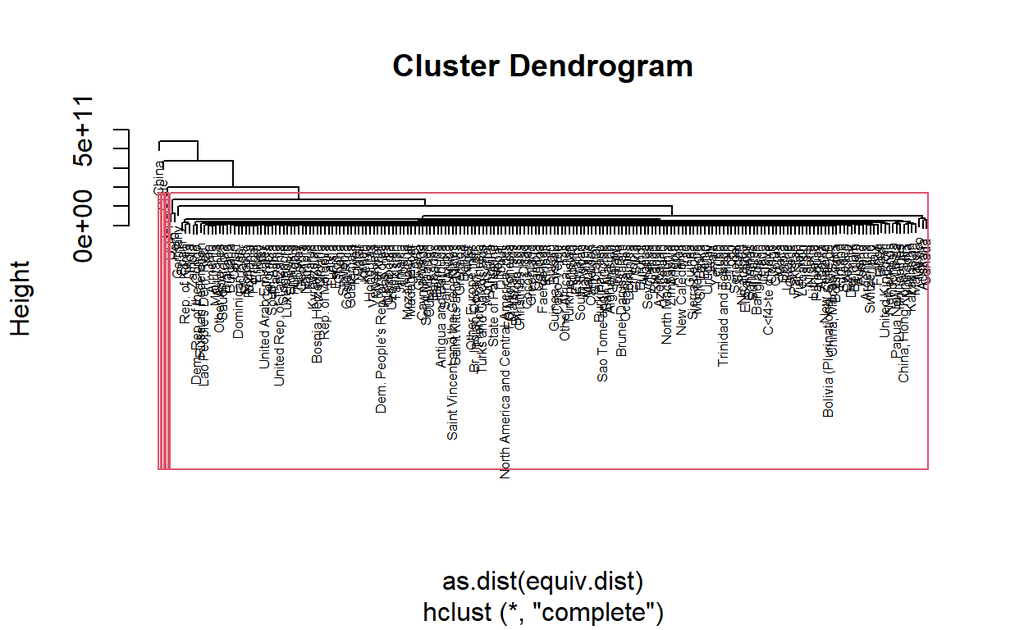

```r
plot(trade.se, labels=trade.se$glabels, cex = 0.5)
rect.hclust(trade.se$cluster,k=4)
```

**From the dendrogram we can observe that China, Chile, and Japan are very different than the rest of 202 countries in exporting copper as they are large copper producing nations. Hence, they form individual clusters. USA and Peru are then very similar in behaviour of trade. Next to them is Germany. There is a lot of trade similarity between the cluster of Spain, Korea, India and cluster of Mexico, Australia, and Canada. The rest of the countries seems to be very similar in trade pattern as they form part of once cluster. However, if we further granularize the countries in various clsuters, more patterns can emerge.**

```r
library(concoR)

# Convert the network to a matrix
mat <- as.matrix(get.adjacency(net.ig))

m0 <- cor(mat) # Calculate a correlation matrix
round(m0, 2)   # Round the output to 2 significant digits
```

[output not shown]

[output cut: 17249 more lines]

```
Niger                                           1.00     0.00
Uganda                                          0.00     0.00
State of Palestine                              0.00     0.00
Andorra                                         0.00     0.00
Chad                                            0.71    -0.01
Cocos Isds                                      1.00     0.00
South Sudan                                     0.00     0.00
Maldives                                        0.00     1.00
Br. Indian Ocean Terr.                          1.00     0.00
Greenland                                       1.00     0.00
Christmas Isds                                  1.00     0.00
French Polynesia                                1.00     0.00
Tuvalu                                          1.00     0.00
Guinea-Bissau                                   1.00     0.00
Eswatini                                        0.00     1.00
```

```r
m0[is.na(m0)] <- 0 #replacing NA values

blks <- concor_hca(list(m0), p = 2)
blks
```

```
    block                                 vertex
1       1                                  Chile
57      2                                Germany
2       1                                  Japan
58      2                                  Congo
106     3                                    USA
3       1                                  China
4       1                                 Zambia
5       1                     Russian Federation
6       1                              Australia
7       1       Bolivia (Plurinational State of)
8       1                               Bulgaria
9       1                                 Canada
10      1                          Rep. of Korea
11      1                        Other Asia, nes
```

[output cut: 191 more lines]